# IE 360 HW 2

### 4.2 Adding Independent and Lagged Variables

```r
#in case of a need, prepare lagged variables
#LAG1
lag1<-shift(data$UGS, n=1L, fill=NA)
data$lag1<-lag1
lmlag1=lm(UGS~trend+Seasons+lag1,data=data)
#summary(lmlag1)
#checkresiduals(lmlag1)
#LAG2
lag2<-shift(data$UGS, n=2L, fill=NA)
data$lag2<-lag2
lmlag2=lm(UGS~trend+Seasons+lag2,data=data)
#summary(lmlag2)
#checkresiduals(lmlag2)
#LAG4
lag4<-shift(data$UGS, n=4L, fill=NA)
data$lag4<-lag4
lmlag4=lm(UGS~trend+Seasons+lag4,data=data)
#summary(lmlag4)
#checkresiduals(lmlag4)
```

One of the variables that has a higher correlation value than other variables is start NDGV

```r
##add NDGV
lm2=lm(UGS~trend+Seasons+NDGV,data=data)
summary(lm2)
```

```
##
## Call:
## lm(formula = UGS ~ trend + Seasons + NDGV, data = data)
##
## Residuals:
##    Min     1Q Median     3Q    Max
## -95177 -20446   4981  23434  58487
##
## Coefficients:
##             Estimate Std. Error t value Pr(>|t|)
## (Intercept) 324530.8   271194.7   1.197 0.244172
## trend       -18430.3     2077.4  -8.872 1.02e-08 ***
## Seasons2    120616.4    22985.2   5.248 2.90e-05 ***
## Seasons3    271579.1    23062.0  11.776 5.70e-11 ***
## Seasons4     90318.6    23226.3   3.889 0.000791 ***
## NDGV          2710.7      996.1   2.721 0.012463 *
## ---
## Signif. codes:  0 '***' 0.001 '**' 0.01 '*' 0.05 '.' 0.1 ' ' 1
##
## Residual standard error: 42950 on 22 degrees of freedom
##   (4 observations deleted due to missingness)
## Multiple R-squared:  0.9341, Adjusted R-squared:  0.9191
## F-statistic: 62.37 on 5 and 22 DF,  p-value: 2.989e-12
```

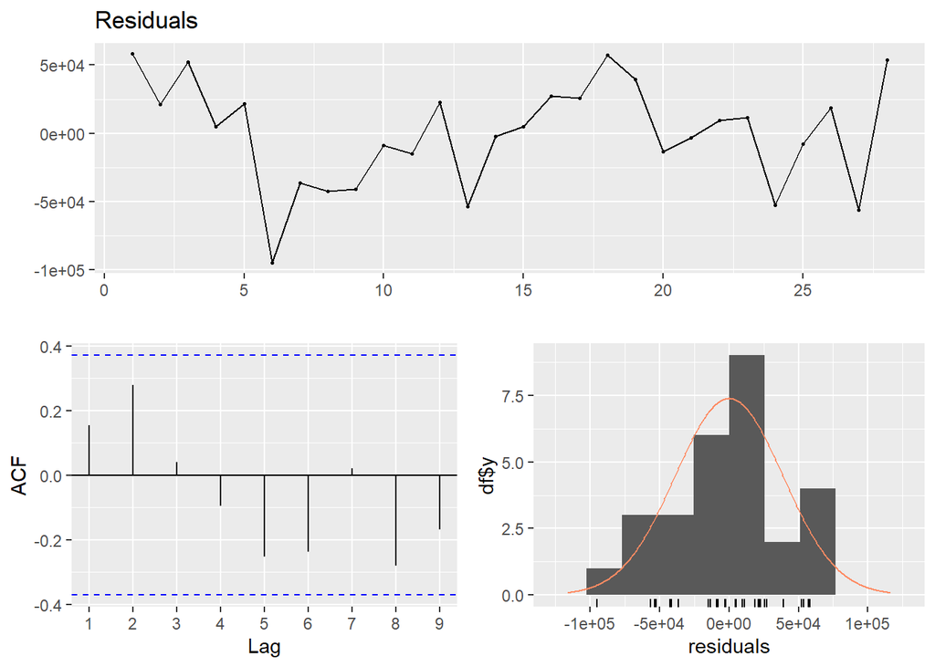

```
##
##  Breusch-Godfrey test for serial correlation of order up to 9
##
## data:  Residuals
## LM test = 18.24, df = 9, p-value = 0.03249
```

```r
checkresiduals(lm2)
```

After adding it adj. R-square value has gone up to 0.9191 and its t-statistic value is significant but residuals tend to have unstable variance thus we need to add some other variables.

```r
##Add NUGV
lm3=lm(UGS~trend+Seasons+NDGV+NUGV,data=data)
summary(lm3)
```

```
##
## Call:
## lm(formula = UGS ~ trend + Seasons + NDGV + NUGV, data = data)
##
## Residuals:
##    Min     1Q Median     3Q    Max
## -67804 -17414   3897  19110  59734
##
## Coefficients:
##               Estimate Std. Error t value Pr(>|t|)
## (Intercept)  1.765e+06  4.825e+05   3.658 0.001467 **
## trend       -6.596e+03  3.908e+03  -1.688 0.106254
## Seasons2     1.242e+05  1.898e+04   6.543 1.76e-06 ***
## Seasons3     2.798e+05  1.917e+04  14.592 1.83e-12 ***
## Seasons4     1.071e+05  1.979e+04   5.412 2.28e-05 ***
## NDGV         6.619e+03  1.421e+03   4.657 0.000135 ***
## NUGV        -5.356e-01  1.590e-01  -3.369 0.002899 **
## ---
## Signif. codes:  0 '***' 0.001 '**' 0.01 '*' 0.05 '.' 0.1 ' ' 1
##
## Residual standard error: 35420 on 21 degrees of freedom
##   (4 observations deleted due to missingness)
## Multiple R-squared:  0.9572, Adjusted R-squared:  0.945
## F-statistic: 78.32 on 6 and 21 DF,  p-value: 2.816e-13
```

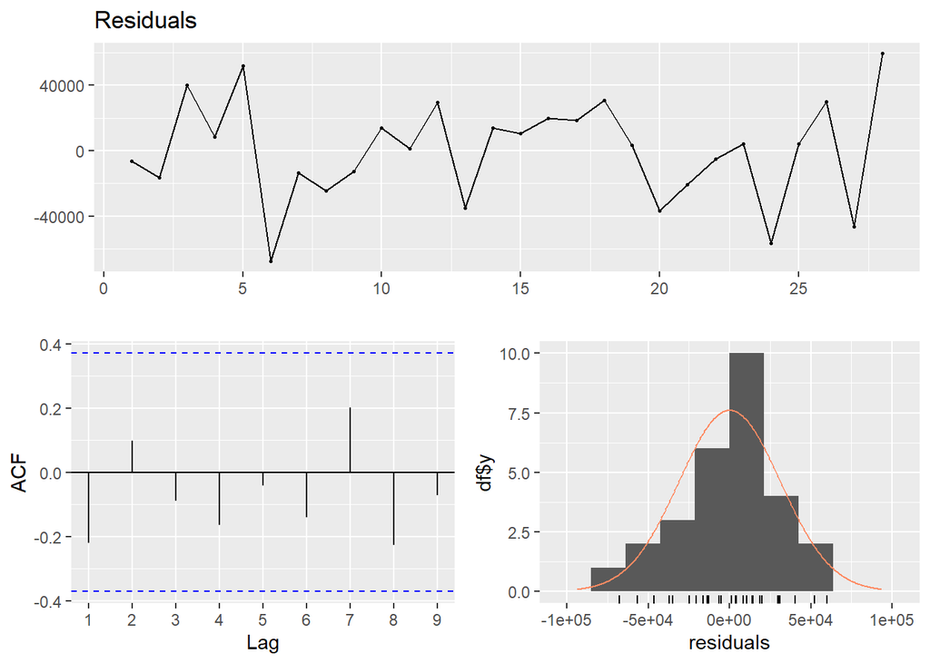

```
##
##  Breusch-Godfrey test for serial correlation of order up to 10
##
## data:  Residuals
## LM test = 14.184, df = 10, p-value = 0.1647
```

```r
checkresiduals(lm3)
```

Adding NUGV increased adj. R-squared and the residuals got closer to 0 with more stable variance. Also they don’t show any high autocorrelation. But still there are remaining variables to be added. We need to try those as well to obtain a better model.

```r
##add GNP.Agriculture
lm4=lm(UGS~trend+Seasons+NDGV+NUGV+GNP.Agriculture,data=data)
summary(lm4)
```

```
##
## Call:
## lm(formula = UGS ~ trend + Seasons + NDGV + NUGV + GNP.Agriculture,
##     data = data)
##
## Residuals:
##    Min     1Q Median     3Q    Max
## -67438 -16121    959  18808  61673
##
## Coefficients:
##                   Estimate Std. Error t value Pr(>|t|)
## (Intercept)      1.638e+06  5.049e+05   3.245 0.004058 **
## trend           -7.435e+03  4.037e+03  -1.842 0.080374 .
## Seasons2         1.112e+05  2.399e+04   4.635 0.000160 ***
## Seasons3         1.487e+05  1.476e+05   1.007 0.325878
## Seasons4         7.376e+04  4.221e+04   1.747 0.095938 .
## NDGV             6.093e+03  1.544e+03   3.946 0.000799 ***
## NUGV            -4.830e-01  1.702e-01  -2.838 0.010174 *
## GNP.Agriculture  2.307e-02  2.576e-02   0.896 0.381058
## ---
## Signif. codes:  0 '***' 0.001 '**' 0.01 '*' 0.05 '.' 0.1 ' ' 1
##
## Residual standard error: 35590 on 20 degrees of freedom
##   (4 observations deleted due to missingness)
## Multiple R-squared:  0.9589, Adjusted R-squared:  0.9445
## F-statistic: 66.62 on 7 and 20 DF,  p-value: 1.785e-12
```

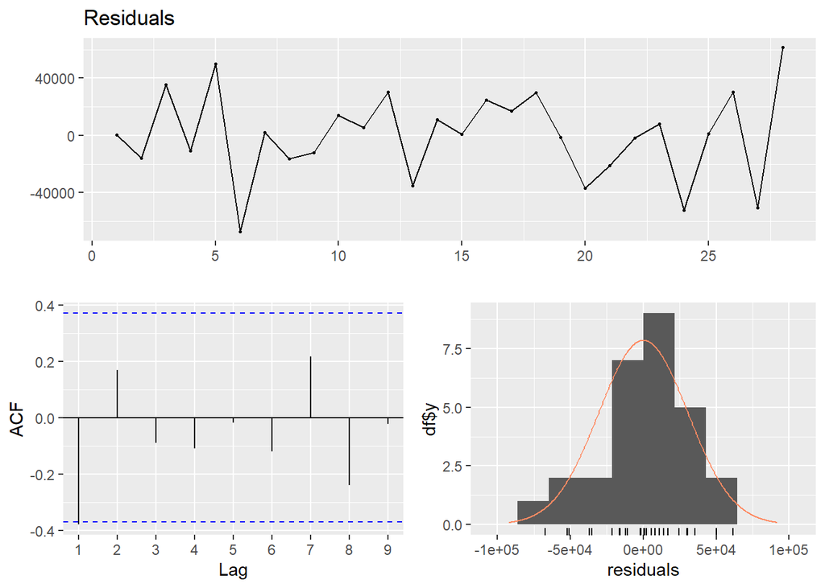

```
##
##  Breusch-Godfrey test for serial correlation of order up to 11
##
## data:  Residuals
## LM test = 17.928, df = 11, p-value = 0.08326
```

```r
checkresiduals(lm4)
```

Adding GNP.Agriculture variable does not show any significance plus, the autocorrelation of residuals at lag 1 has gone up after adding it so we can drop it.

```r
#add PG
lm5=lm(UGS~trend+Seasons+NDGV+PG+NUGV,data=data)
summary(lm5)
```

```
##
## Call:
## lm(formula = UGS ~ trend + Seasons + NDGV + PG + NUGV, data = data)
##
## Residuals:
##    Min     1Q Median     3Q    Max
## -59059 -13018    822  15582  54366
##
## Coefficients:
##               Estimate Std. Error t value Pr(>|t|)
## (Intercept)  1.942e+06  4.200e+05   4.623 0.000164 ***
## trend       -3.554e+03  3.527e+03  -1.007 0.325749
## Seasons2     1.279e+05  1.640e+04   7.801 1.72e-07 ***
## Seasons3     2.879e+05  1.675e+04  17.187 1.91e-13 ***
## Seasons4     1.042e+05  1.708e+04   6.102 5.79e-06 ***
## NDGV         6.996e+03  1.231e+03   5.682 1.46e-05 ***
## PG          -6.535e+02  2.267e+02  -2.883 0.009198 **
## NUGV        -5.508e-01  1.370e-01  -4.020 0.000672 ***
## ---
## Signif. codes:  0 '***' 0.001 '**' 0.01 '*' 0.05 '.' 0.1 ' ' 1
##
## Residual standard error: 30510 on 20 degrees of freedom
##   (4 observations deleted due to missingness)
## Multiple R-squared:  0.9698, Adjusted R-squared:  0.9592
## F-statistic: 91.69 on 7 and 20 DF,  p-value: 8.4e-14
```

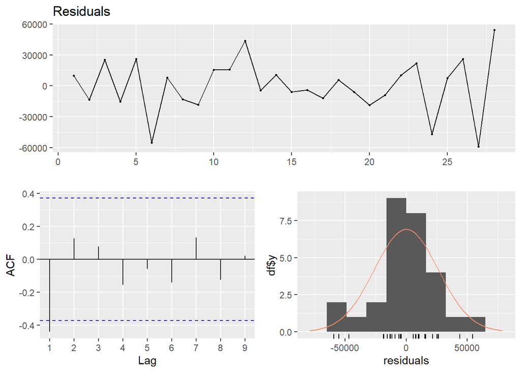

```
##
##  Breusch-Godfrey test for serial correlation of order up to 11
##
## data:  Residuals
## LM test = 18, df = 11, p-value = 0.08159
```

```r
checkresiduals(lm5)
```

Adding PG also shows significance but there is still autocorrelation at lag 1 for residuals. To reduce the effect at lag one we can add lag1 variable into our model and observe the results.

```r
#add lag 1
lm6=lm(UGS~trend+Seasons+NDGV+PG+NUGV+lag1,data=data)
summary(lm6)
```

```
##
## Call:
## lm(formula = UGS ~ trend + Seasons + NDGV + PG + NUGV + lag1,
##     data = data)
##
## Residuals:
##    Min     1Q Median     3Q    Max
## -43631 -13550  -3959  20638  42723
##
## Coefficients:
##               Estimate Std. Error t value Pr(>|t|)
## (Intercept)  2.803e+06  6.319e+05   4.436 0.000319 ***
## trend       -6.720e+03  3.724e+03  -1.804 0.087931 .
## Seasons2     8.955e+04  2.469e+04   3.626 0.001930 **
## Seasons3     3.071e+05  1.790e+04  17.161 1.33e-12 ***
## Seasons4     1.928e+05  4.224e+04   4.564 0.000240 ***
## NDGV         9.833e+03  2.123e+03   4.631 0.000208 ***
## PG          -7.836e+02  2.231e+02  -3.513 0.002486 **
## NUGV        -7.773e-01  2.097e-01  -3.707 0.001614 **
## lag1        -4.504e-01  2.015e-01  -2.235 0.038316 *
## ---
## Signif. codes:  0 '***' 0.001 '**' 0.01 '*' 0.05 '.' 0.1 ' ' 1
##
## Residual standard error: 28260 on 18 degrees of freedom
##   (5 observations deleted due to missingness)
## Multiple R-squared:  0.9758, Adjusted R-squared:  0.9651
## F-statistic: 90.88 on 8 and 18 DF,  p-value: 5.777e-13
```

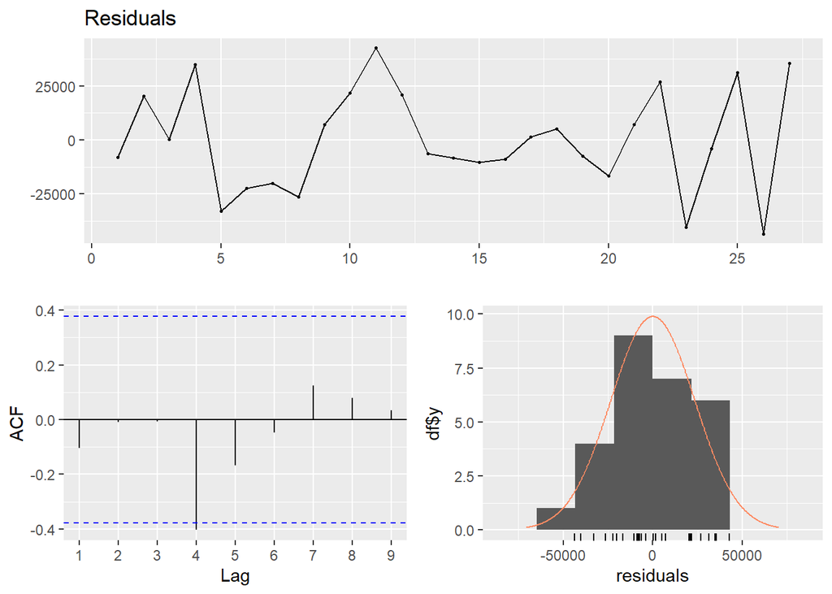

```
##
##  Breusch-Godfrey test for serial correlation of order up to 12
##
## data:  Residuals
## LM test = 16.832, df = 12, p-value = 0.156
```

```r
checkresiduals(lm6)
```

Adding lag 1 variable increased adj-R square and residuals got closer to 0 compared to others but this time the residuals shows high correlation at lag 4. To reduce that also lets add lag 4 variable.

```r
#add lag 4
lm7=lm(UGS~trend+Seasons+NDGV+PG+NUGV+lag1+lag4,data=data)
summary(lm7)
```

```
##
## Call:
## lm(formula = UGS ~ trend + Seasons + NDGV + PG + NUGV + lag1 +
##     lag4, data = data)
##
## Residuals:
##    Min     1Q Median     3Q    Max
## -44105 -15706  -5382  14675  45964
##
## Coefficients:
##               Estimate Std. Error t value Pr(>|t|)
## (Intercept)  2.931e+06  9.405e+05   3.117  0.00757 **
## trend       -9.953e+03  5.839e+03  -1.705  0.11033
## Seasons2     1.090e+05  3.501e+04   3.113  0.00763 **
## Seasons3     3.495e+05  6.449e+04   5.419 9.04e-05 ***
## Seasons4     2.076e+05  5.380e+04   3.859  0.00174 **
## NDGV         1.033e+04  4.165e+03   2.481  0.02642 *
## PG          -7.160e+02  2.563e+02  -2.794  0.01436 *
## NUGV        -7.958e-01  3.729e-01  -2.134  0.05101 .
## lag1        -4.578e-01  2.310e-01  -1.982  0.06748 .
## lag4        -1.664e-01  2.117e-01  -0.786  0.44488
## ---
## Signif. codes:  0 '***' 0.001 '**' 0.01 '*' 0.05 '.' 0.1 ' ' 1
##
## Residual standard error: 30570 on 14 degrees of freedom
##   (8 observations deleted due to missingness)
## Multiple R-squared:  0.9629, Adjusted R-squared:  0.939
## F-statistic: 40.35 on 9 and 14 DF,  p-value: 1.756e-08
```

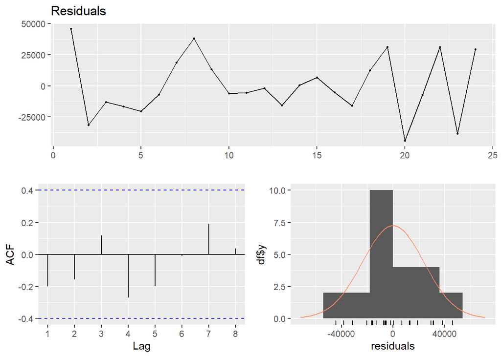

```
##
##  Breusch-Godfrey test for serial correlation of order up to 13
##
## data:  Residuals
## LM test = 23.955, df = 13, p-value = 0.03154
```

```r
checkresiduals(lm7)
```

adding lag 4 decreases adj R-square and increased residual mean. To compare these models well we can also draw q-q plots and fitted vs. residuals plots.

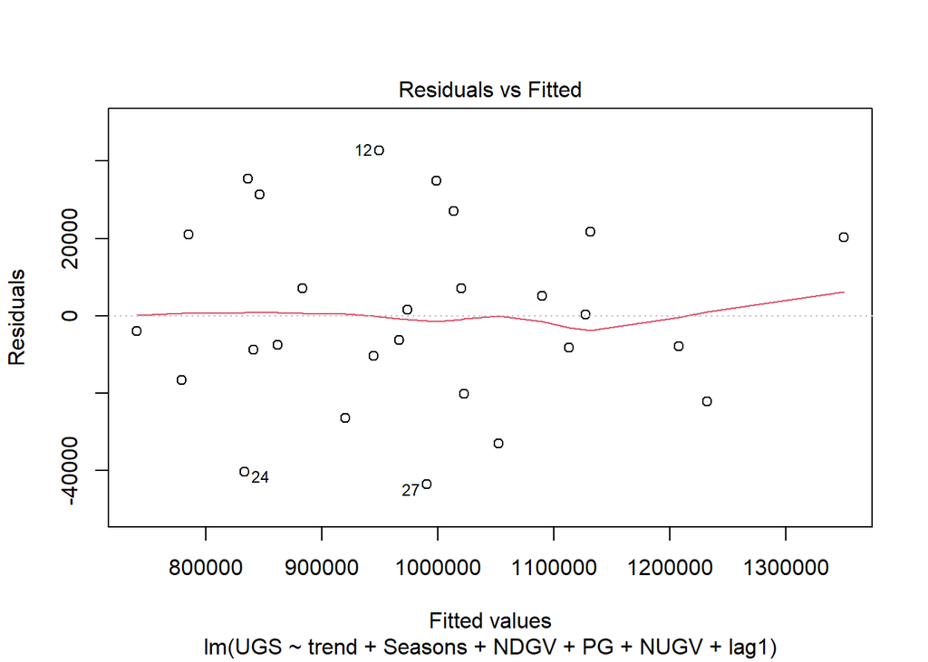

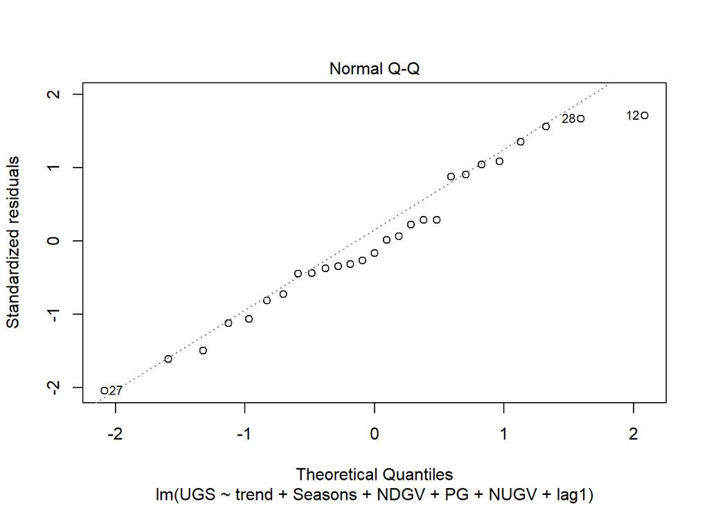

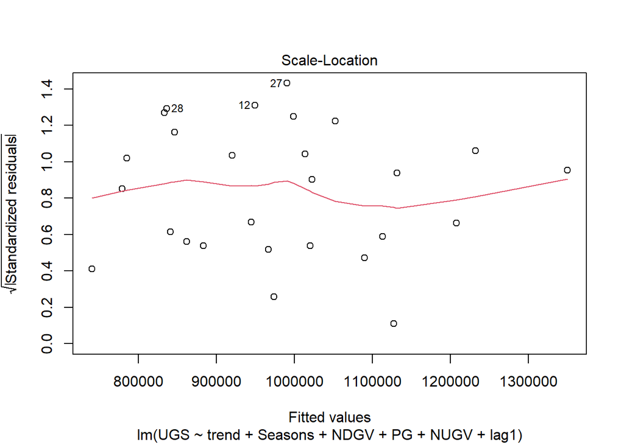

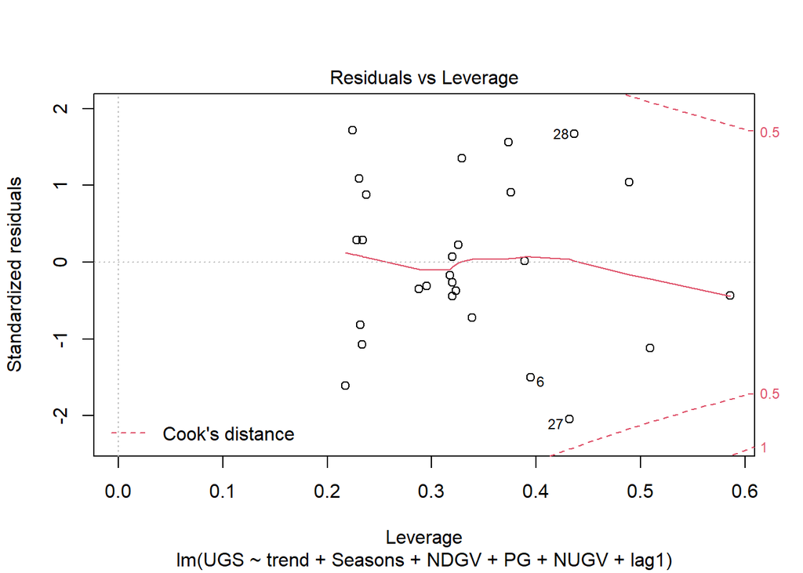

```r
#Plot lm6
plot(lm6)
```

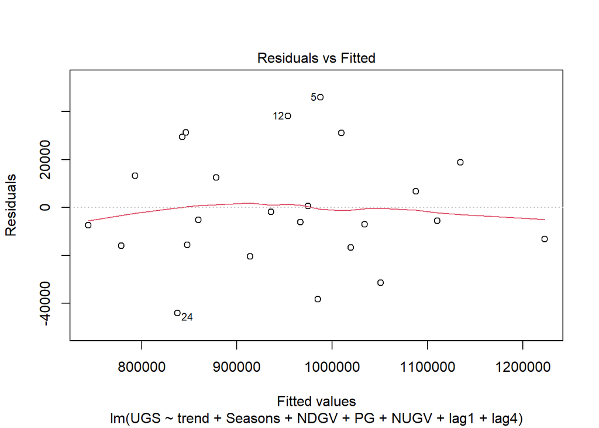

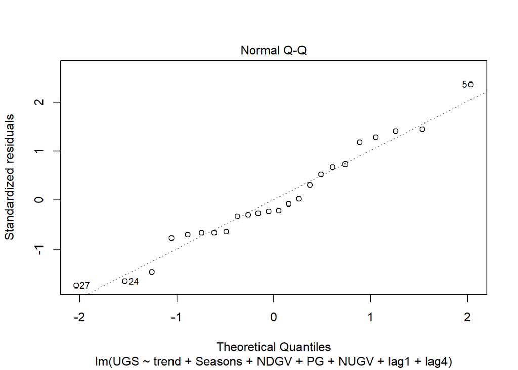

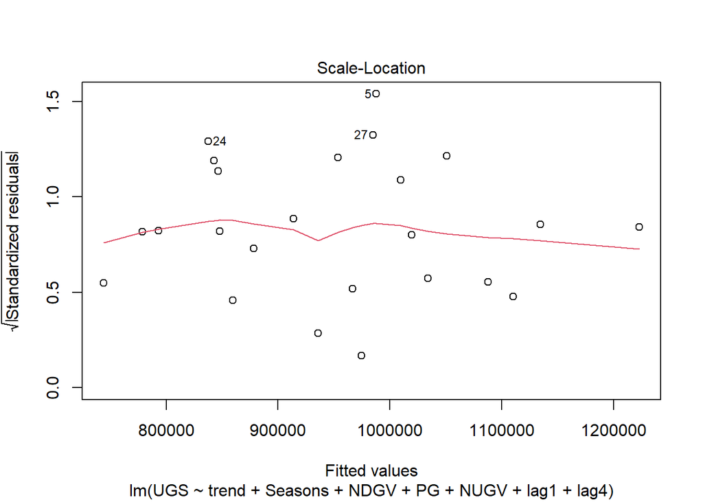

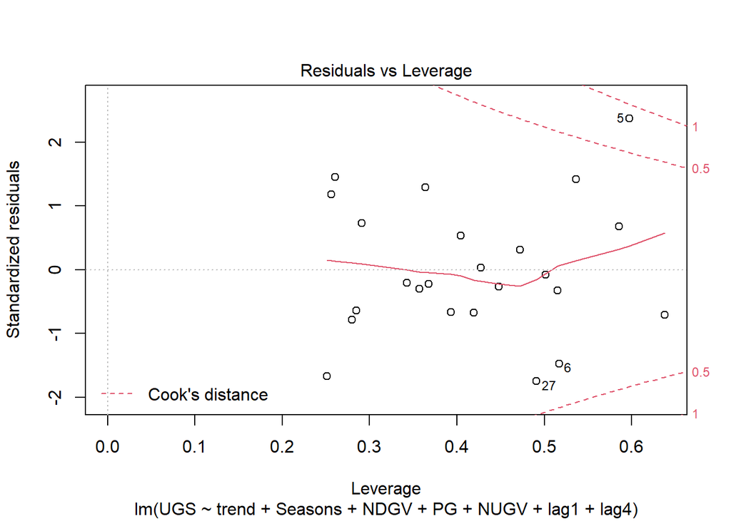

```r
#plot lm7
plot(lm7)
```

It can be seen that linear model 6 is better since its both “q-q” plot and “residual vs fitted” shows more like normally distributed residuals with 0 mean. Thus our model for the predictions will be lm6.

## 5.Fitting the Model and Prediction

### 5.1 Fitting the Model

```r
tmp=copy(data)
is.data.frame(tmp)
```

```
## [1] TRUE
```

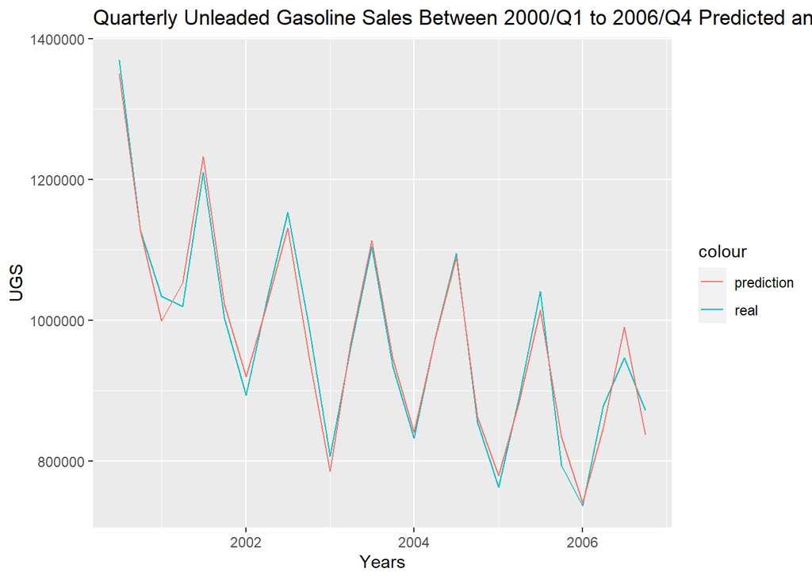

```r
actual<-tmp$UGS
predicted<-predict(lm6,tmp)
tmp$actual<-actual
tmp$predicted<-predicted

#plot the predicted value and the actual ones
ggplot(tmp[c(3:28),], aes(x=Quarter))+geom_line(aes(y=actual, color="real"))+geom_line(aes(y=predicted, color="prediction"))+theme_grey()+
  ggtitle("Quarterly Unleaded Gasoline Sales Between 2000/Q1 to 2006/Q4 Predicted and Actual Values")+xlab("Years")+ylab("UGS")
```

Above, predicted values and actual values are displayed. They behave very similar.

### 5.2 Predicting the Next 4 Quarters.

```r
predictions=predict(lm6,newdata =data[29:32,])
predictions
```

```
##     29     30     31     32
## 666210     NA     NA     NA
```

As we use lagged 1 variable we need to use predicted values as observations for the next prediction until an observed values is obtained. Thus the following has to be done:

```r
tmp[ 30, "lag1"] = predictions[1]
tmp$predictions2<-predict(lm6,tmp)

tmp[ 31, "lag1"] = tmp$predictions2[30]
tmp$predictions2<-predict(lm6,tmp)

tmp[ 32, "lag1"] = tmp$predictions2[31]
tmp$predictions2<-predict(lm6,tmp)
```

Now plot with forecasted values:

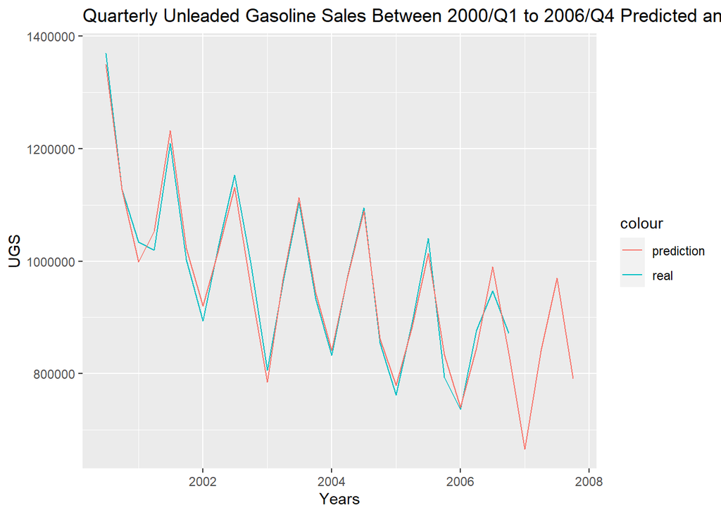

```r
#With forecasted values
ggplot(tmp[c(3:32),], aes(x=Quarter))+geom_line(aes(y=actual, color="real"))+geom_line(aes(y=predictions2, color="prediction"))+theme_grey()+
  ggtitle("Quarterly Unleaded Gasoline Sales Between 2000/Q1 to 2006/Q4 Predicted and Actual Values")+xlab("Years")+ylab("UGS")
```

### 5.3 Predicted Values

```r
results<-data.frame(`predicted UGS sales`=tmp$predictions2[29:32],row.names=c("2007-Q1","2007-Q2","2007-Q3","2007-Q4"))
results
```

```
##         predicted.UGS.sales
## 2007-Q1            666210.0
## 2007-Q2            840163.9
## 2007-Q3            970373.9
## 2007-Q4            790375.4
```

## 6. Conclusion

After trying many models, the final ended up to be a regression model where the target variable is Unleaded Gasoline Sales **(UGS)** and independent variables ended up to be

- **PG:***Average price (adjusted with an index) of a liter of diesel gasoline in a quarter,*
- **NUGV:***Number of unleaded gasoline using vehicles in the traffic,*
- **NDGV:***Number of diesel gasoline using vehicles in the traffic,*
- **lag1***:Lagged 1 variable*.